# Introduction to gridmicrotex

## What is gridmicrotex?

**gridmicrotex** renders LaTeX math equations as native R `grid` graphics objects (grobs). It uses the MicroTeX C++ library as its layout engine — MicroTeX parses LaTeX, builds the TeX box model, and computes exact glyph coordinates. The package intercepts this layout data and maps it to native grid primitives (`pathGrob`, `segmentsGrob`, `rectGrob`, `textGrob`), producing a `gTree` that works on any R graphics device at any resolution.

**Key features:**

- No external LaTeX installation required — MicroTeX is fully embedded
- Resolution-independent vector output on all R devices (PNG, PDF, SVG, …)
- Full math support: fractions, roots, integrals, matrices, Greek letters, accents, delimiters, and more
- Two bundled math fonts: Lete Sans Math (sans-serif, default) and STIX Two Math (serif); additional fonts via `load_font()`
- Color support via `\textcolor{}`
- ggplot2 integration with `geom_latex()` and `element_latex()`
- CJK and multilingual text in `\text{}` blocks

## Basic usage

The core function is `latex_grob()`, which returns a grid grob:

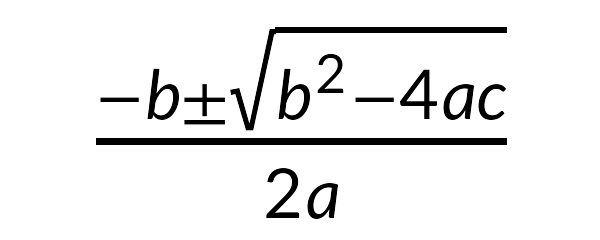

```r
library(gridmicrotex)
library(grid)

g <- latex_grob("\\frac{-b \\pm \\sqrt{b^2 - 4ac}}{2a}", gp = grid::gpar(fontsize = 24))
grid::grid.newpage()
grid::grid.draw(g)
```

For quick rendering, use `grid.latex()`:

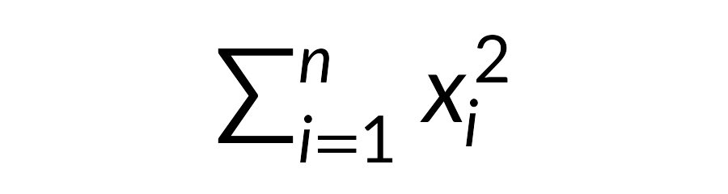

```r
grid::grid.newpage()
grid.latex("$\\sum_{i=1}^{n} x_i^2$", gp = grid::gpar(fontsize = 28))
```

## Positioning and justification

Control placement with `x`, `y`, `hjust`, and `vjust`:

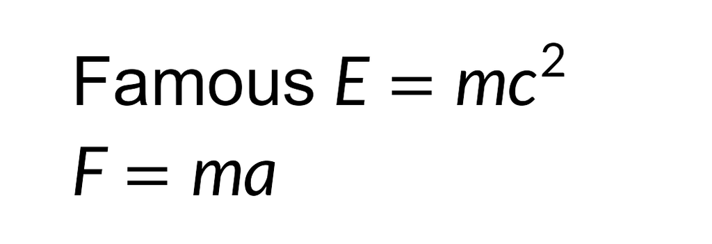

```r
grid::grid.newpage()
grid.latex("Famous $E = mc^2$", x = 0.1, y = 0.7, hjust = 0, gp = grid::gpar(fontsize = 24))
grid.latex("F = ma", x = 0.1, y = 0.3, hjust = 0, gp = grid::gpar(fontsize = 24), input_mode = "math")
```

### Aligning to the math baseline

In addition to numeric justifications in `[0, 1]`, `hjust` and `vjust` also accept named values. The most useful one is `vjust = "baseline"`, which places the formula’s math baseline (not the bbox centre) on the anchor point — so a formula sits next to surrounding text the way it would in a typeset document.

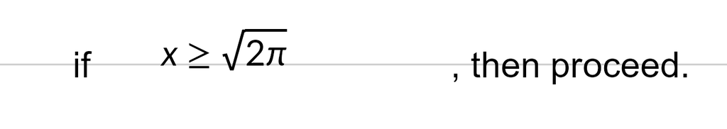

```r
grid::grid.newpage()
y <- 0.5
grid::grid.segments(unit(0, "npc"), unit(y, "npc"),
                    unit(1, "npc"), unit(y, "npc"),
                    gp = grid::gpar(col = "grey80"))
grid::grid.text("if ", x = 0.10, y = y, just = c(0, 0.5),
                gp = grid::gpar(fontsize = 16))
grid.latex("$x \\geq \\sqrt{2\\pi}$",
           x = 0.22, y = y,
           hjust = "left", vjust = "baseline",
           gp = grid::gpar(fontsize = 16))
grid::grid.text(", then proceed.", x = 0.62, y = y, just = c(0, 0.5),
                gp = grid::gpar(fontsize = 16))
```

`hjust` accepts `"left"`/`"bbleft"`, `"center"`/`"centre"`/`"middle"`/ `"bbcentre"`, and `"right"`/`"bbright"`. `vjust` accepts `"bottom"`, `"center"`/`"centre"`/`"middle"`, `"top"`, and `"baseline"`.

### Named anchors with `\mark{}`

The `\mark{name}` macro records a named anchor at its position inside the formula. `grobMark()` then resolves the anchor to a pair of grid units, ready to drive an arrow, callout, or any other grob.

A mark works at any nesting level — between top-level tokens, on a compound sub-expression like `b^2`, even inside a superscript or fraction. The position inherits the surrounding transform (font shrink for scripts, scaling, rotation), so the anchor lands on the rendered glyph rather than a pre-layout offset.

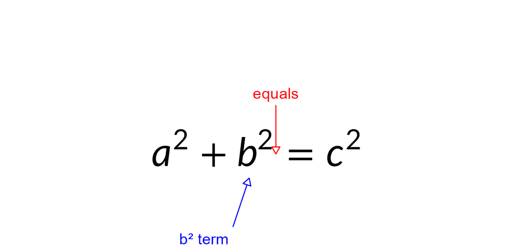

```r
g <- latex_grob(
  r"($a^2 + b\mark{term}^2 \mark{equals}= c^2$)",
  x = 0.5, y = 0.4,
  gp = grid::gpar(fontsize = 28)
)
grid::grid.newpage()
grid::grid.draw(g)

# Callout 1: the "=" sign, pointed at from above.
mk_eq <- grobMark(g, "equals")
grid::grid.segments(mk_eq$x, mk_eq$y + unit(15, "mm"),
                    mk_eq$x, mk_eq$y + unit(3, "mm"),
                    arrow = grid::arrow(length = unit(2, "mm"), type = "closed"),
                    gp = grid::gpar(col = "red"))
grid::grid.text("equals", x = mk_eq$x, y = mk_eq$y + unit(18, "mm"),
                gp = grid::gpar(col = "red", fontsize = 11))

# Callout 2: the b^2 term, pointed at from below — the mark sits at the
# end of the term, including the superscript's smaller scale.
mk_bsq <- grobMark(g, "term")
grid::grid.segments(mk_bsq$x - unit(6, "mm"), mk_bsq$y - unit(15, "mm"),
                    mk_bsq$x - unit(2, "mm"), mk_bsq$y - unit(3, "mm"),
                    arrow = grid::arrow(length = unit(2, "mm"), type = "closed"),
                    gp = grid::gpar(col = "blue"))
grid::grid.text("b² term",
                x = mk_bsq$x - unit(7, "mm"),
                y = mk_bsq$y - unit(18, "mm"),
                just = "right",
                gp = grid::gpar(col = "blue", fontsize = 11))
```

Because the returned units carry the grob’s viewport position and `hjust`/`vjust`, you can pass them straight to `grid.points`, `grid.segments`, or any other grid drawing function — no manual offset arithmetic.

`\mark` records a single point, not a span. To centre a callout over a multi-glyph term, place the mark at the term’s end and shift in your drawing code, or place a pair of marks (`\mark{l}…\mark{r}`) and use their midpoint.

## Colors

You can use `r"()"` raw strings to write LaTeX with regular newlines and quotes without escaping. Set the formula color via `gp`, or use `\textcolor{}` within the LaTeX:

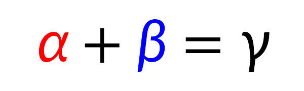

```r
latex_options(input_mode = "math") # Set math mode globally
grid::grid.newpage()
grid.latex(
  r"(\textcolor{red}{\alpha} + \textcolor{blue}{\beta} = \gamma)",
  gp = grid::gpar(fontsize = 28)
)
```

## Math fonts

The package ships with two math fonts, both loaded automatically:

| Alias | Font | License |
| --- | --- | --- |
| `"lete"` (default) | Lete Sans Math | SIL Open Font License |
| `"stix"` | STIX Two Math | SIL Open Font License |

```r
available_math_fonts()
```

```
#> [1] "Lete Sans Math" "STIX Two Math"
```

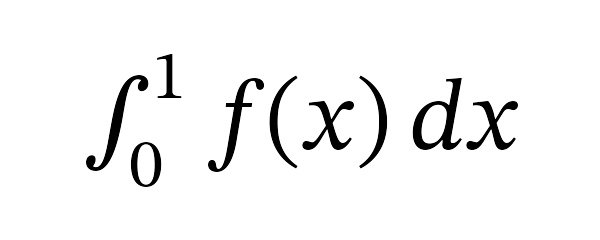

```r
latex_options(math_font = "stix")
grid::grid.newpage()
grid.latex(r"(\int_0^1 f(x)\,dx)", gp = grid::gpar(fontsize = 24))
```

```r
# Switch back to the default (Lete Sans Math)
latex_options(math_font = "lete")
```

You can also override the font per call via `math_font`:

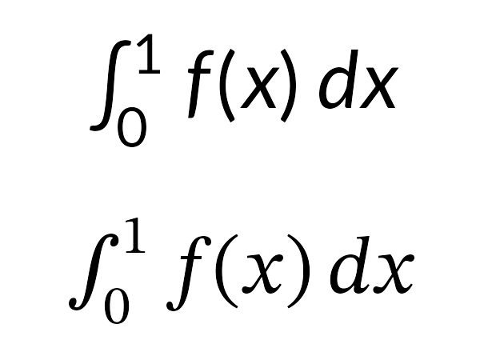

```r
grid::grid.newpage()
grid::pushViewport(grid::viewport(layout = grid::grid.layout(2, 1)))
grid::pushViewport(grid::viewport(layout.pos.row = 1))
grid.latex(r"(\int_0^1 f(x)\,dx)", gp = grid::gpar(fontsize = 24))
grid::upViewport()
grid::pushViewport(grid::viewport(layout.pos.row = 2))
grid.latex(r"(\int_0^1 f(x)\,dx)", gp = grid::gpar(fontsize = 24), math_font = "stix")
grid::upViewport(2)
```

Use `available_math_fonts()` to list loaded fonts and `check_fonts()` for a diagnostic report.

### Advanced: loading custom fonts

Use `load_font()` to add any additional OpenType math font. The OpenType MATH table is parsed directly in C++ — no companion metrics file or external toolchain is required:

```r
load_font("path/to/MyFont.otf")
```

### Render modes

gridmicrotex supports two rendering modes for math glyphs:

- **`"typeface"`** (default): Renders glyphs as native text using the math font’s typeface. This produces selectable, searchable, and accessible text in PDF and SVG output. Bundled math fonts (Lete Sans Math, STIX Two Math) and any registered via `load_font()` are read directly from their OTF files — no system-wide font install is required. Requires a device that supports the R 4.3 glyph engine (e.g., `ragg::agg_png()`, `svglite::svglite()`, `grDevices::cairo_pdf()`). On devices that do not (e.g., the base `pdf()` device), the package automatically falls back to path mode with a warning.
- **`"path"`**: Renders each glyph as a filled vector path. This works on all R graphics devices and produces pixel-perfect output. However, text in PDF/SVG output is not selectable or searchable.

```r
# Default typeface mode (selectable text in PDF/SVG)
grid.latex("E = mc^2", gp = grid::gpar(fontsize = 24))

# Explicit path mode (works everywhere, but text is not selectable)
grid.latex("E = mc^2", gp = grid::gpar(fontsize = 24), render_mode = "path")
```

> **Important: Do not use `showtext::showtext_auto()` with typeface mode.** The showtext package globally intercepts all text rendering and converts it to vector paths. This silently defeats typeface mode, causing all math glyphs to appear as paths instead of native text — even on devices like `svglite` and `ragg` that fully support font embedding. If you need showtext for other parts of your plot, disable it before drawing LaTeX formulas:

> ```r
> showtext::showtext_auto(FALSE)
> grid.latex("E = mc^2", gp = grid::gpar(fontsize = 24))  # typeface mode works correctly
> ```

## Querying dimensions

`latex_dims()` returns the bounding box of an expression:

```r
dims <- latex_dims("\\frac{a}{b}", gp = grid::gpar(fontsize = 20))
dims
```

```
#> $width
#> [1] 7bigpts
#>
#> $height
#> [1] 25bigpts
#>
#> $depth
#> [1] 9bigpts
#>
#> $baseline
#> [1] 9.36317294836044bigpts
#>
#> $is_split
#> [1] FALSE
```

This is useful for layout calculations and ensuring labels fit.

## Text rendering and CJK support

Text inside `\text{}` and `\mbox{}` is rendered using R’s standard text-rendering system. This means `gp$fontfamily` controls the font for **all** text content — Latin letters, CJK characters, Cyrillic, and any other script your R graphics device supports:

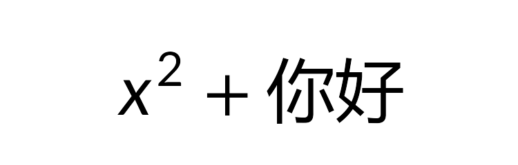

```r
grid::grid.newpage()
grid.latex("x^2 + \\text{你好}", gp = grid::gpar(fontsize = 24, fontfamily = "sans"))
```

Any font available to R works: base families like `"sans"`, `"serif"`, `"mono"`, or fonts registered via **showtext** / **systemfonts**.

### Font pairing

The bundled math fonts have different styles. For a consistent look, pair them with a matching `fontfamily`:

| Math font | Style | Suggested `fontfamily` |
| --- | --- | --- |
| Lete Sans Math (`"lete"`, default) | Sans-serif | `"sans"` |
| STIX Two Math (`"stix"`) | Serif | `"serif"` |

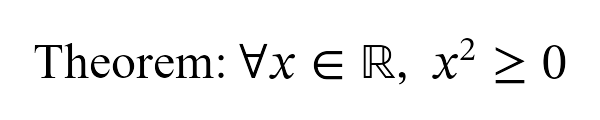

```r
grid::grid.newpage()
grid.latex(
  "\\text{Theorem: } \\forall x \\in \\mathbb{R},\\; x^2 \\geq 0",
  math_font = "stix",
  gp = grid::gpar(fontfamily = "serif", fontsize = 12)
)
```

## Supported LaTeX

gridmicrotex uses the MicroTeX engine, which is a **math formula renderer**, not a full document typesetter. It covers the vast majority of math notation you would use in plots and figures, but does not attempt to replace a full LaTeX installation.

### Complicated examples

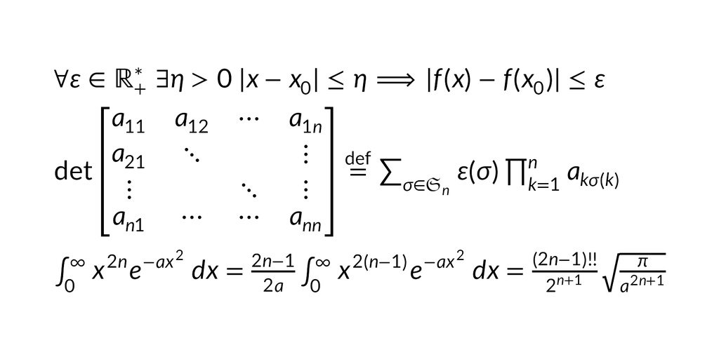

```r
grid::grid.newpage()
grid.latex(paste0(
      "\\begin{array}{l}",
      "  \\forall\\varepsilon\\in\\mathbb{R}_+^*\\ \\exists\\eta>0",
      "\\ |x-x_0|\\leq\\eta\\Longrightarrow|f(x)-f(x_0)|\\leq\\varepsilon\\\\",
      "  \\det",
      "  \\begin{bmatrix}",
      "      a_{11}&a_{12}&\\cdots&a_{1n}\\\\",
      "      a_{21}&\\ddots&&\\vdots\\\\",
      "      \\vdots&&\\ddots&\\vdots\\\\",
      "      a_{n1}&\\cdots&\\cdots&a_{nn}",
      "  \\end{bmatrix}",
      "  \\overset{\\mathrm{def}}{=}\\sum_{\\sigma\\in\\mathfrak{S}_n}",
      "\\varepsilon(\\sigma)\\prod_{k=1}^n a_{k\\sigma(k)}\\\\",
      "  \\int_0^\\infty{x^{2n} e^{-a x^2}\\,dx} = \\frac{2n-1}{2a}",
      " \\int_0^\\infty{x^{2(n-1)} e^{-a x^2}\\,dx}",
      " = \\frac{(2n-1)!!}{2^{n+1}} \\sqrt{\\frac{\\pi}{a^{2n+1}}}\\\\",
      "\\end{array}"
), gp = grid::gpar(fontsize = 16))
```

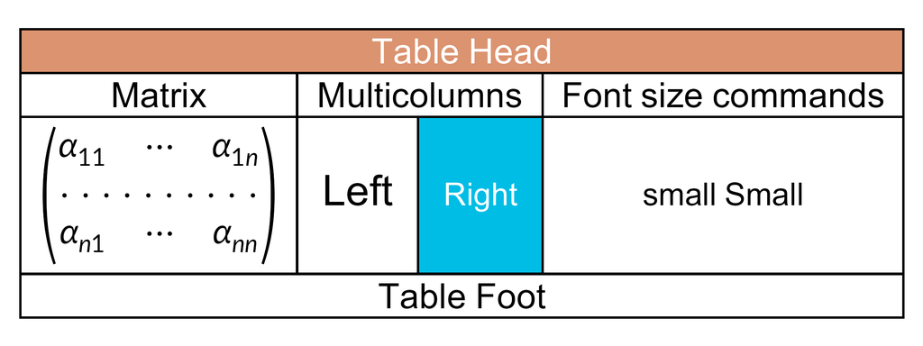

```r
grid::grid.newpage()

grid.latex(
  "
  \\newcolumntype{s}{>{\\color{#1234B6}}c}
\\begin{array}{|c|c|c|s|}
  \\hline
  \\rowcolor{Tan}\\multicolumn{4}{|c|}{\\textcolor{white}{\\bold{\\text{Table Head}}}}\\\\
  \\hline
  \\text{Matrix}&\\multicolumn{2}{|c|}{\\text{Multicolumns}}&\\text{Font size commands}\\\\
  \\hline
  \\begin{pmatrix}
      \\alpha_{11}&\\cdots&\\alpha_{1n}\\\\
      \\hdotsfor{3}\\\\
      \\alpha_{n1}&\\cdots&\\alpha_{nn}
  \\end{pmatrix}
  &\\large \\text{Left}&\\cellcolor{#00bde5}\\small \\textcolor{white}{\\text{\\bold{Right}}}
  &\\small \\text{small Small}\\\\
  \\hline
  \\multicolumn{4}{|c|}{\\text{Table Foot}}\\\\
  \\hline
\\end{array}
  ",
  gp = grid::gpar(fontsize = 22)
)
```

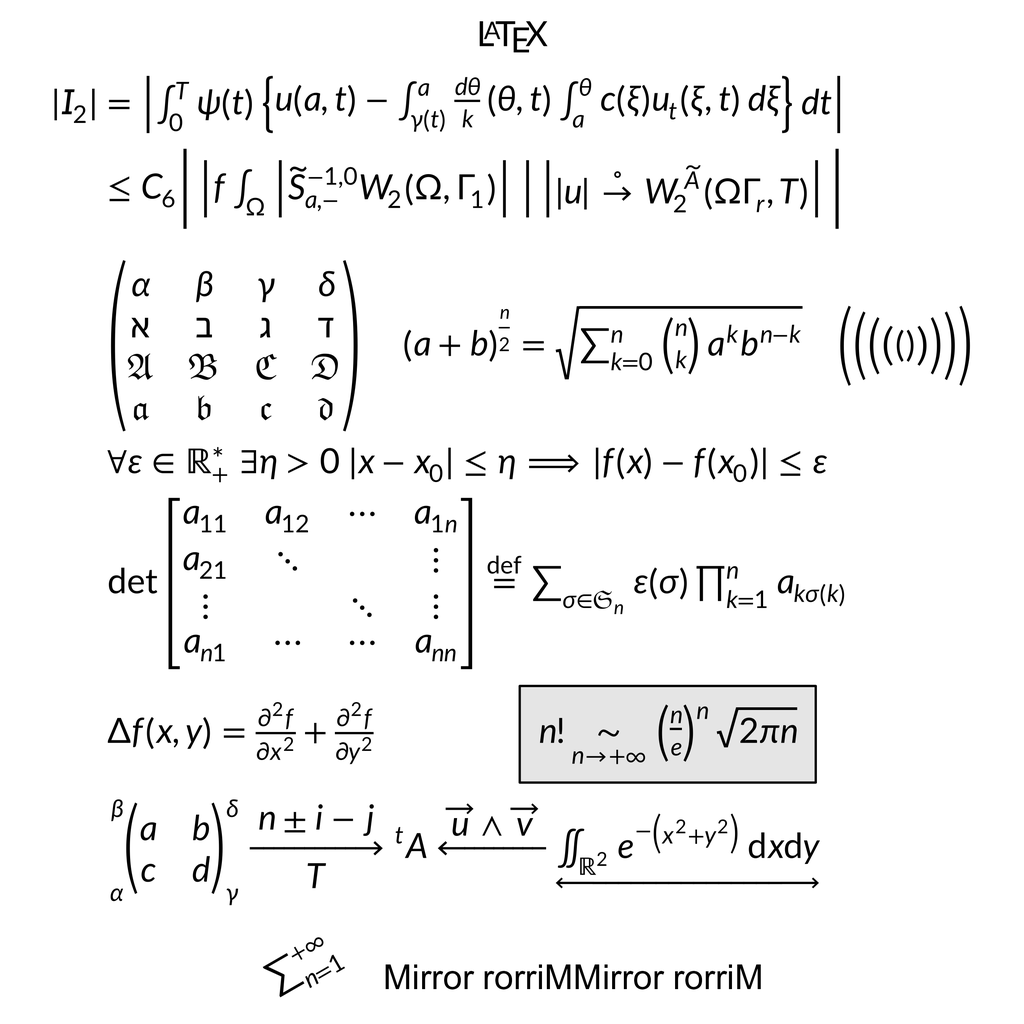

```r
grid::grid.newpage()
grid.latex(
  "\\definecolor{gris}{gray}{0.9}
\\definecolor{noir}{rgb}{0,0,0}
\\definecolor{bleu}{rgb}{0,0,1}
\\fatalIfCmdConflict{false}
\\newcommand{\\pa}{\\left|}
\\begin{array}{c}
  \\LaTeX\\\\
  \\begin{split}
      |I_2| &= \\pa\\int_0^T\\psi(t)\\left\\{ u(a,t)-\\int_{\\gamma(t)}^a \\frac{d\\theta}{k} (\\theta,t) \\int_a^\\theta c(\\xi)
          u_t (\\xi,t)\\,d\\xi\\right\\}dt\\right|\\\\
      &\\le C_6 \\Bigg|\\pa f \\int_\\Omega \\pa\\widetilde{S}^{-1,0}_{a,-}
          W_2(\\Omega, \\Gamma_1)\\right|\\ \\right|\\left| |u|\\overset{\\circ}{\\to} W_2^{\\widetilde{A}}(\\Omega\\Gamma_r,T)\\right|\\Bigg|\\\\
      &\\\\
      &\\begin{pmatrix}
          \\alpha&\\beta&\\gamma&\\delta\\\\
          \\aleph&\\beth&\\gimel&\\daleth\\\\
          \\mathfrak{A}&\\mathfrak{B}&\\mathfrak{C}&\\mathfrak{D}\\\\
          \\boldsymbol{\\mathfrak{a}}&\\boldsymbol{\\mathfrak{b}}&\\boldsymbol{\\mathfrak{c}}&\\boldsymbol{\\mathfrak{d}}
      \\end{pmatrix}
      \\quad{(a+b)}^{\\frac{n}{2}}=\\sqrt{\\sum_{k=0}^n\\tbinom{n}{k}a^kb^{n-k}}\\quad
          \\Biggl(\\biggl(\\Bigl(\\bigl(()\\bigr)\\Bigr)\\biggr)\\Biggr)\\\\
      &\\forall\\varepsilon\\in\\mathbb{R}_+^*\\ \\exists\\eta>0\\ |x-x_0|\\leq\\eta\\Longrightarrow|f(x)-f(x_0)|\\leq\\varepsilon\\\\
      &\\det
      \\begin{bmatrix}
          a_{11}&a_{12}&\\cdots&a_{1n}\\\\
          a_{21}&\\ddots&&\\vdots\\\\
          \\vdots&&\\ddots&\\vdots\\\\
          a_{n1}&\\cdots&\\cdots&a_{nn}
      \\end{bmatrix}
      \\overset{\\mathrm{def}}{=}\\sum_{\\sigma\\in\\mathfrak{S}_n}\\varepsilon(\\sigma)\\prod_{k=1}^n a_{k\\sigma(k)}\\\\
      &\\Delta f(x,y)=\\frac{\\partial^2f}{\\partial x^2}+\\frac{\\partial^2f}{\\partial y^2}\\qquad\\qquad \\fcolorbox{noir}{gris}
          {n!\\underset{n\\rightarrow+\\infty}{\\sim} {\\left(\\frac{n}{e}\\right)}^n\\sqrt{2\\pi n}}\\\\
      &\\sideset{_\\alpha^\\beta}{_\\gamma^\\delta}{
      \\begin{pmatrix}
          a&b\\\\
          c&d
      \\end{pmatrix}}
      \\xrightarrow[T]{n\\pm i-j}\\sideset{^t}{}A\\xleftarrow{\\overrightarrow{u}\\wedge\\overrightarrow{v}}
          \\underleftrightarrow{\\iint_{\\mathds{R}^2}e^{-\\left(x^2+y^2\\right)}\\,\\mathrm{d}x\\mathrm{d}y}
  \\end{split}\\\\
  \\rotatebox{30}{\\sum_{n=1}^{+\\infty}}\\quad\\mbox{Mirror rorriM}\\reflectbox{\\mbox{Mirror rorriM}}
\\end{array}",
  gp = grid::gpar(fontsize = 22),
  render_mode = "path"
)
```

### Lists

The `itemize` and `enumerate` environments lay their items out as a left-aligned column, one item per row — `itemize` prefixes each item with a bullet, `enumerate` numbers them:

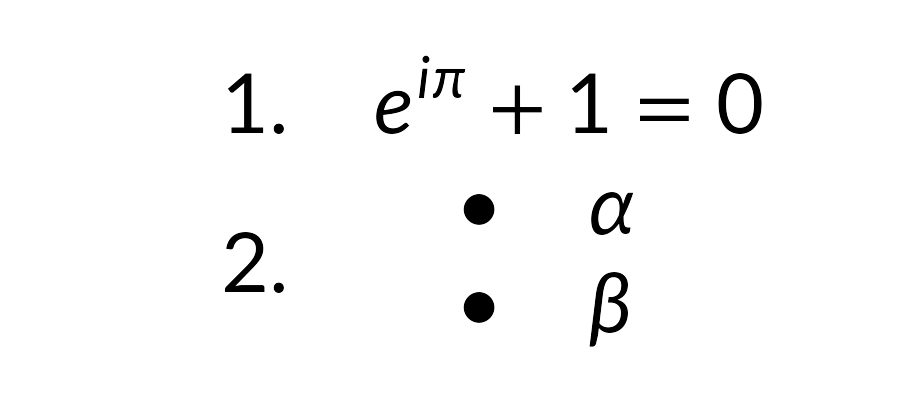

```r
grid::grid.newpage()
grid.latex(paste0(
  "\\begin{enumerate}",
  "  \\item e^{i\\pi} + 1 = 0",
  "  \\item \\begin{itemize}",
  "           \\item \\alpha \\item \\beta",
  "         \\end{itemize}",
  "\\end{enumerate}"
), gp = grid::gpar(fontsize = 20))
```

An optional `[…]` argument customises the marker. For `itemize` it is the literal marker (`\begin{itemize}[\star]`); for `enumerate` it is a counter template containing one of `\arabic*`, `\alph*`, `\Alph*`, `\roman*`, or `\Roman*` (e.g. `\begin{enumerate}[\Roman*.]`). Lists may nest, and an item may contain any math — including a `\begin{array}` table.

Because MicroTeX is a math engine, each item is typeset as a **math-mode, single-line** expression: there is no paragraph flow or line wrapping, and prose inside an item must be wrapped in `\text{}` (e.g. `\item \text{First point}`). The `description` environment is not supported.

### Pasting LaTeX from other sources

When the input is generated by tools that emit complete LaTeX — for example R packages that produce ready-to-compile `tabular` snippets, or LaTeX fragments copy-pasted from a `.tex` file — the formula often arrives wrapped in document-level constructs that MicroTeX does not implement. Rather than refusing such input, gridmicrotex rewrites or removes a small set of well-known wrappers before parsing.

**Removed silently (no visual effect):**

| Construct | Why |
| --- | --- |
| `%`-to-end-of-line comments (`\%` is preserved) | comments are non-visual in LaTeX too |
| `\documentclass[…]{…}`, `\usepackage[…]{…}` | preamble metadata |
| `\begin{document}` / `\end{document}` | document boundary, structural only |
| `\maketitle`, `\title{…}`, `\author{…}` | title-page metadata, no body output |
| `\label{…}` | cross-reference target, never rendered in LaTeX either |
| `\begin{table}[…]` / `\end{table}`, `\begin{figure}[…]` / `\end{figure}` (and starred variants) | float wrappers; the contents stay |
| `\centering`, `\raggedright`, `\raggedleft`, `\flushleft`, `\flushright` | alignment scope declarations |
| `\noindent`, `\relax` | content-free declarations |

**Rewritten to a MicroTeX equivalent:**

| Construct | Becomes |
| --- | --- |
| `\emph{X}` | `\textit{X}` |
| `\textnormal{X}` | `\text{X}` |
| `\par`, `\newline` | `\\` (line break) |
| `\toprule`, `\bottomrule` | `\thickhline` (rendered ~2× thickness) |
| `\midrule` | `\hline` |
| `\cmidrule[trim]?(parenarg)?{a-b}` | `\cline{a-b}` — partial-column rule |
| `\caption[short]{X}` | `\text{X}\\` inserted inline at source position |
| `\smallskip`, `\medskip`, `\bigskip` | `\vspace{0.25em}` / `\vspace{0.5em}` / `\vspace{1em}` — em-relative so they scale with `gp$fontsize` |
| `\hfill`, `\vfill` | `\quad` / `\vspace{1em}` — static proxies for rubber lengths |

A note on `\caption`: in real LaTeX, captions are repositioned by the float machinery (typically above or below the surrounding `tabular`, independent of source order). Here the caption renders exactly where it appears in the source. For tools that place `\caption` after `\end{tabular}`, this gives a caption-below-table layout; for tools that place it before, you get caption-above.

A note on the skips and fills: real LaTeX defines `\smallskip` / `\medskip` / `\bigskip` as absolute `pt` amounts (3 / 6 / 12). The mapping above uses em-relative values instead, so the gap stays visible whether `gp$fontsize` is 10 or 30. If you need an exact absolute size, use `\vspace{Xpt}` directly — MicroTeX accepts pt, em, ex, mm, cm.

`\hfill` and `\vfill` are *rubber* lengths in LaTeX — they expand to fill the surrounding glue. A fixed-size grob has nothing to “fill,” so the mapping produces a static 1em gap. The position is right; the elasticity is gone.

**Not honored (rendered as literal text, which is intentional — it makes unsupported markup easy to spot):**

- Declarative font scopes: `\bfseries`, `\itshape`, `\ttfamily`, `\sffamily`, `\rmfamily`. These affect text within their group in LaTeX, which requires scope tracking we do not implement. Use the argument-bearing forms instead: `\textbf{…}`, `\textit{…}`, `\texttt{…}`, `\textsf{…}`, `\textrm{…}`, all of which MicroTeX supports natively.
- Hyperlinks and references: `\url{…}`, `\href{…}{…}`, `\ref{…}`, `\cite{…}`. There is no link concept inside a grob.
- Footnotes: `\footnote{…}` (positioning machinery is page-bound).
- Small caps: `\textsc{…}` (MicroTeX has no small-caps glyphs).

### What is not supported

MicroTeX is a **math formula renderer**, not a full LaTeX engine. The following are outside its scope and would need a real document compiler:

- **Document structure**: `\section`, page layout, headers/footers, `\tableofcontents`
- **Package loading semantics**: `\usepackage{…}` is accepted but loads nothing — supported commands are all built into MicroTeX
- **Paragraph text**: line breaking, hyphenation, justified paragraphs
- **TikZ / PGF** drawing commands
- **Images**: `\includegraphics`
- **Cross-references**: targets via `\label` are silently dropped; `\ref`, `\cite`, bibliographies have nothing to resolve against
- **Theorem environments**: `\begin{theorem}`, `\begin{proof}`
- **The `description` list environment** (`itemize` and `enumerate` *are* supported — see *Lists* above)
- **Some amsmath commands**: `\tag` and equation numbering

For most statistical graphics use cases — axis labels, annotations, legends, and in-plot formulas — the supported feature set is more than sufficient.

## Project-wide defaults

`latex_options()` sets defaults for `math_font` and `render_mode`, used by `latex_grob()`, `grid.latex()`, `latex_dims()`, and `latex_tree()` whenever the corresponding argument is not supplied at the call site. Size is controlled at the grob level via `gp$fontsize` / `gp$lineheight` (see *Basic usage*).

```r
latex_options(math_font = "stix", render_mode = "typeface")

# Later calls pick these up automatically
grid.latex("\\sum_{i=1}^{n} i^{2}", gp = grid::gpar(fontsize = 14))

# Query current settings
latex_options()

# Reset to built-in defaults
reset_latex_options()
```

Explicit arguments always win. Setting `math_font` via `latex_options()` also updates the MicroTeX engine default, so you don’t also need a separate font-setup call.

## User-defined macros

`define_macro()` registers zero-argument shorthands that are expanded by text substitution before the expression reaches MicroTeX. Handy for recurring notation:

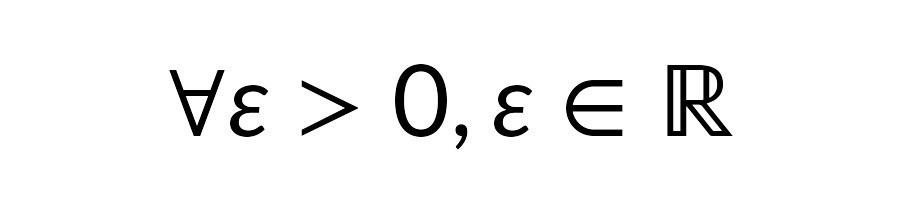

```r
define_macro("RR", "\\mathbb{R}")
define_macro("eps", "\\varepsilon")

grid::grid.newpage()
grid.latex("\\forall \\eps > 0, \\eps \\in \\RR", gp = grid::gpar(fontsize = 24))
```

```r
clear_macros()
```

Macro names must be ASCII letters. Expansion iterates to a fixed point, so macros can reference other macros. Use `list_macros()` to see currently registered ones, and `clear_macros()` (with no arguments) to drop them all.

For parameterised macros (0–9 arguments) scoped to a single expression, MicroTeX also accepts plain-TeX `\def`:

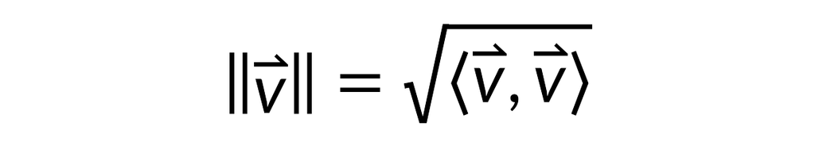

```r
grid::grid.newpage()
grid.latex(
  r"(\def\norm#1{\left\lVert #1 \right\rVert}
      \def\inner#1#2{\langle #1, #2 \rangle}
      \norm{\vec{v}} = \sqrt{\inner{\vec{v}}{\vec{v}}})",
  gp = grid::gpar(fontsize = 24)
)
```

`\def` definitions live only for the duration of the expression they appear in, so they are the right tool for a parameterised abbreviation local to one label. Reach for `define_macro()` instead when you want a shorthand to persist across many plots in the same R session.

## Layout caching

Parsed layouts are memoised by `(tex, fontsize, math_font, render_mode, ...)`. Re-drawing the same formula — for example, the same axis label across many plots — reuses the cached layout:

```r
latex_cache_info()       # size / max_size / hits / misses
latex_cache_limit(1024)  # raise or lower the LRU capacity
latex_cache_clear()      # wipe the cache (e.g. after re-loading fonts)
```

Set the limit to `0` to disable caching entirely.

## Introspecting a formula

`latex_tree()` returns the raw draw-record table plus bbox metadata, useful for debugging alignment, counting glyphs, or building custom grobs on top of the layout:

```r
tr <- latex_tree("\\frac{a}{b}")
tr
```

```
#> <latex_tree>
#>   tex:         \frac{a}{b}
#>   render_mode: typeface
#>   bbox:        width=7.00  height=25.00  depth=9.00  baseline=0.63 (bigpts)
#>   records:     3
#>     glyph      2
#>     line       1
```

```r
head(tr$records, 3)
```

```
#>    type         x      y glyph font_size   color    x2     y2 width height rx
#> 1 glyph 0.1890002  7.196  3628        14 #000000    NA     NA    NA     NA NA
#> 2  line 0.0000000 10.596    NA        NA #000000 7.392 10.596    NA     NA NA
#> 3 glyph 0.0000000 25.796  3629        14 #000000    NA     NA    NA     NA NA
#>   ry  lwd text font_style rotation path codepoint
#> 1 NA   NA <NA>         NA        0 NULL        NA
#> 2 NA 1.32 <NA>         NA        0 NULL        NA
#> 3 NA   NA <NA>         NA        0 NULL        NA
#>                                                                                           font_file
#> 1 C:/Users/alim/AppData/Local/Temp/RtmpKyA5XL/Rinst128442f24153/gridmicrotex/fonts/LeteSansMath.otf
#> 2                                                                                              <NA>
#> 3 C:/Users/alim/AppData/Local/Temp/RtmpKyA5XL/Rinst128442f24153/gridmicrotex/fonts/LeteSansMath.otf
```

## Debug overlay

Pass `debug = TRUE` to `latex_grob()` / `grid.latex()` to overlay diagnostics on the rendered formula — the full bounding box (dashed gray), the baseline (solid red), and a dot at each draw record’s origin. Useful for checking vertical alignment between a formula and surrounding grobs:

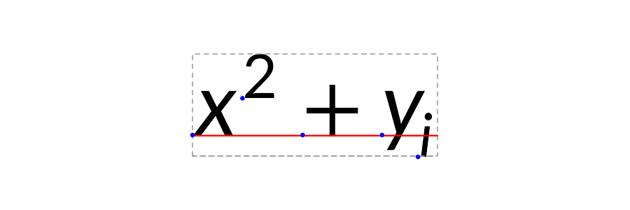

```r
grid::grid.newpage()
grid.latex("x^{2} + y_{i}", gp = grid::gpar(fontsize = 30), debug = TRUE)
```

## Comparison with alternatives

| Approach | LaTeX required? | Device independent? | Vector? | Math coverage |
| --- | --- | --- | --- | --- |
| `tikzDevice` | Yes | No | Yes | Full |
| `xdvir` | Yes | No | Yes | Full |
| `latexpdf` | Yes | No | Yes | Full (tables) |
| `latex2exp` | No | Yes | Yes | Limited |
| `plotmath` | No | Yes | Yes | Limited |
| **gridmicrotex** | **No** | **Yes** | **Yes** | **Broad** |

## Graphics backend

The default graphics device on Windows (`windows()`) and macOS (`quartz()`) may not find the bundled math fonts, producing warnings like:

```
font family not found in Windows font database
```

To avoid this, switch to a modern graphics backend that uses systemfonts for font resolution:

```r
# For knitr / R Markdown --- add to your setup chunk:
knitr::opts_chunk$set(dev = "ragg_png")

# For interactive use:
options(device = function(...) ragg::agg_png(tempfile(fileext = ".png"), ...))
```

Recommended backends:

| Backend | Format | Package |
| --- | --- | --- |
| `ragg::agg_png()` | PNG | ragg |
| `svglite::svglite()` | SVG | svglite |
| `grDevices::cairo_pdf()` | PDF | Base R (Cairo build) |

Alternatively, use `render_mode = "path"` to bypass font lookup entirely — glyphs are drawn as vector paths, which works on all devices but produces non-selectable text in PDF/SVG.